Quick! Name a creature with four wings!

Is it mythical? Fictional? Born of the imagination? Well, nature once had an answer. Enter Basal Dromaeosaurids, a group of maniraptoran theropods found in Liaoning, China, that could grow wings on each of their arms and legs. They were small, at roughly 77cm length, with long tails that had few vertebrae but many feathers. Researchers believe that Basal Dromaeosaurids’ light skeletal structure coupled with its numerous wings and feathers allowed them to glide through the air, providing evidence for a tetrapteryx stage in bird evolution between strict movement on land and flight. Fun fact: the tetrapteryx stage was originally theorized by the ornithologist William Beebe all the way back in 1915, and the Basal Dromaeosaurids were the first fossil evidence to support it, being discovered in 2003. That’s 88 years from when the hypothesis was proposed!

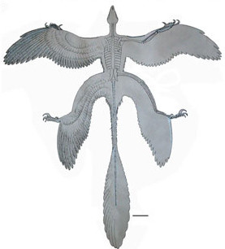

*The Basal Dromaeosaurid Microraptor Gui, with four wings and some tail feathers.*

Each of the Basal Dromaeosaurid wings was also found to have similar features for gliding, such as the presence of asymmetric pennaceous (quill-like) feathers. These findings suggest that each of Basal Dromaeosaurids’ wings were suitable for gliding, and that each of them were used equally. Yet, the researchers concluded that Basal Dromaeosaurids likely could not flap their wings fast enough to take flight given their weight. They had some of the necessary features for flight though, making them “pre-adapted” for flight similar to Archeopteryx.

In addition, Basal Dromaeosaurids had long feathers on their feet. While this characteristic likely aided their gliding, it also may have been a hindrance their running speed. This possibility would contradict the ground-up hypothesis for the origin of avian flight, as Basal Dromaeosaurids would not be able to run fast enough to take off. Further, given Basal Dromaeosaurids small size and ability to glide, the researchers inferred that they were likely arboreal creatures (i.e., they lived in trees).